# The Complexity of Being Human

## Review: What is wrong with this representation?

[figure not shown]

- **The “March of Progress” is one of the most iconic — and most misleading — images in science communication.**
- **Reality: Evolution is not a straight line; it’s a branching tree**
- **Reality: Evolution has no goal or direction**
  - evolution is not creating modern humans as an ‘end goal’
- **Reality: There were many species of hominins with varied adaptations**
- **It reinforces misleading hierarchies from primitive to advanced humans**

## The complexity of being human

- **In addition to other harmful fallacies this cartoon propagates, it makes “being human” seem very separate, and very independent**
  - As we evaluate the role of humans in global change, are any of these things true?

[figure not shown]

## Human Independence Revisited

*Homo sapiens* wouldn’t exist without our complex evolutionary, ecological, and societal associations

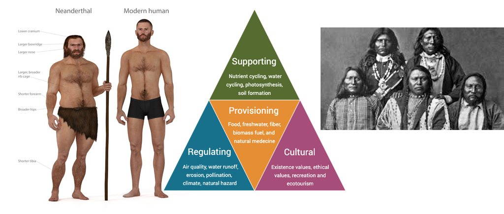

## Is independence just another human fallacy?

- **This isn’t only “external” but also internal**
- **Example 1: your microbiome**
  - 1,000 - 10,000 species in human body
  - ~80-100 genera
- **39 trillion microbial cells including bacteria, viruses and fungi live on-in us**
  - ‘cell-wise’ the human body is 43% human
- **Human microbiome has 500x more genes than human**

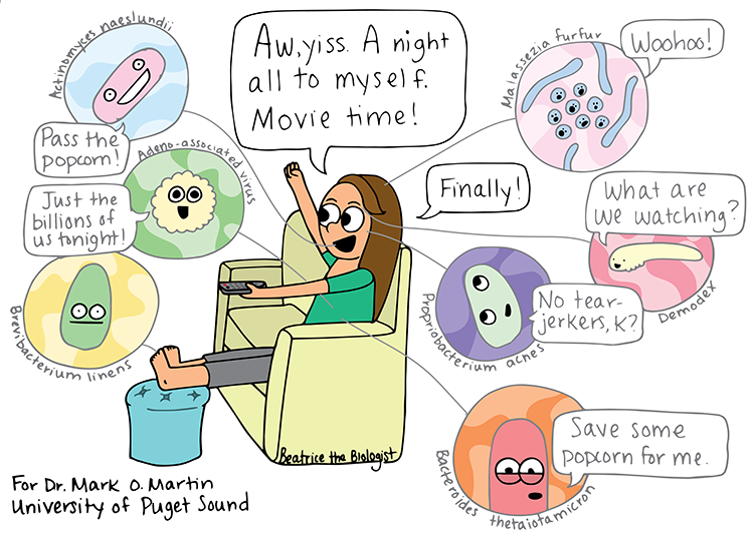

## How independent are we?

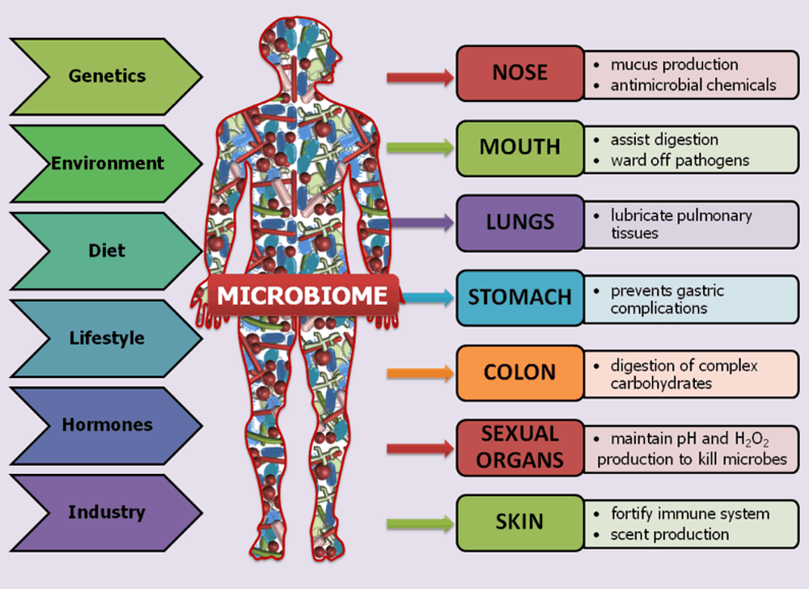

## What does it mean to be *Homo sapiens*?

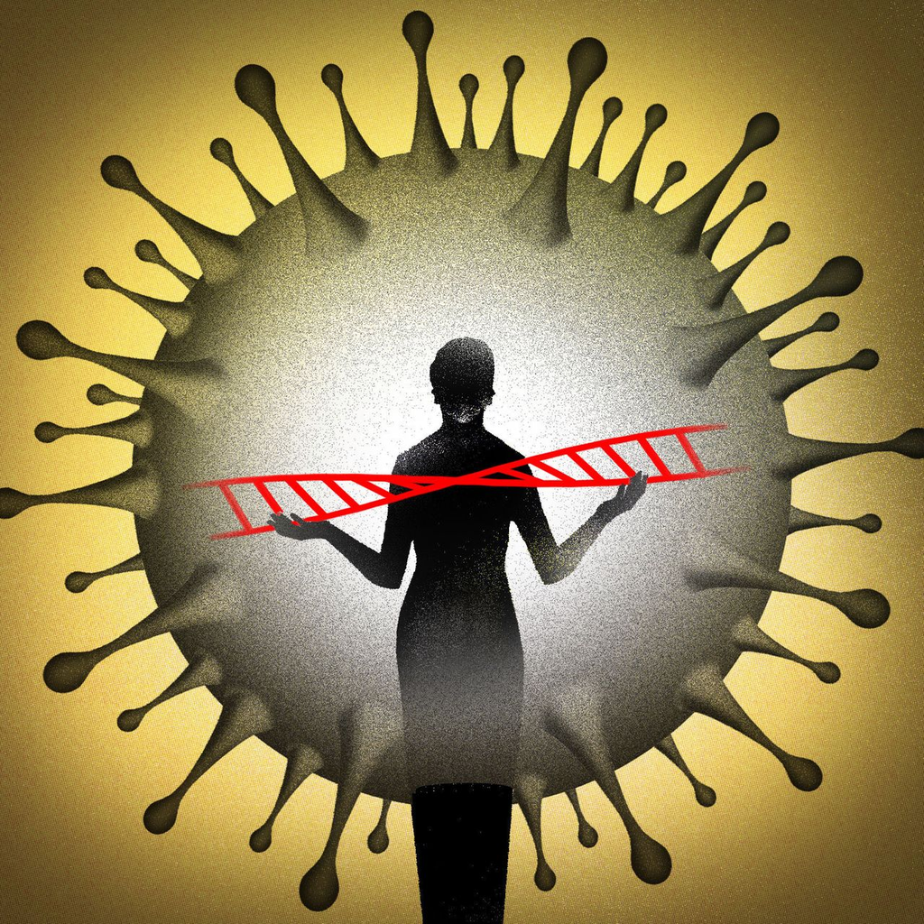

- **Example 2: (barely) hidden in your DNA**
- **~8% of human genome ancient *viral* insertions inherited in our DNA**
- **~30-40% of the human genome is repetitive DNA which may also have viral origins**
- **100,000 pieces of ancient viral DNA live among our genes**
  - function, if any, has long been unclear

## What does it mean to be *Homo sapiens*?

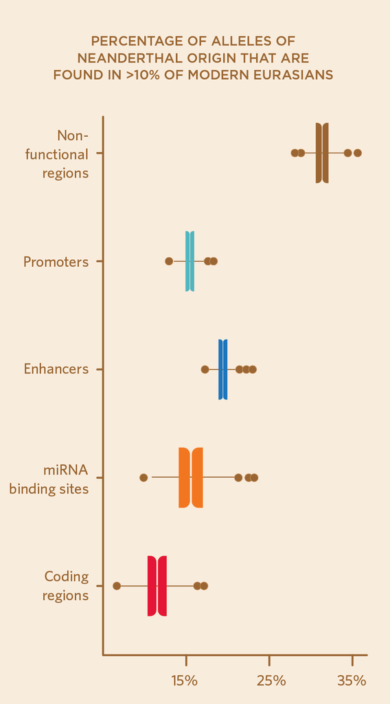

- **Example 2: (barely) hidden in your DNA**
- **Most humans have 1-2% Neanderthal DNA**
  - remember - both species co-existed and sometimes mated
- **Neanderthal gene variants range in expression from skin and hair color to immune function and neuropsychiatric disease**
  - may have left us prone to allergies!
  - may have caused some to have higher risks from Covid!
  - possible genetic links to depression and addiction

## What does it mean to be *Homo sapiens*?

[figure not shown]

- **Example 2: (barely) hidden in your DNA**
- **Denisovans left genetic traces in oceanic and Asian regions**
  - genomes of Australian aborigines, New Guineans and Pacific Islanders ~5% Denisovan
  - East and South Asians up to 0.5%
- **Denisovan gene variants range in diverse expression of immunity, metabolism and neurology**
  - variants in Tibetans regulate hemoglobin levels to allow survival at high altitudes
  - may allow better pathogen recognition and defense in Asian populations
  - variant in zinc transporter gene associated with predisposition to depression

## What does it mean to be *Homo sapiens*?

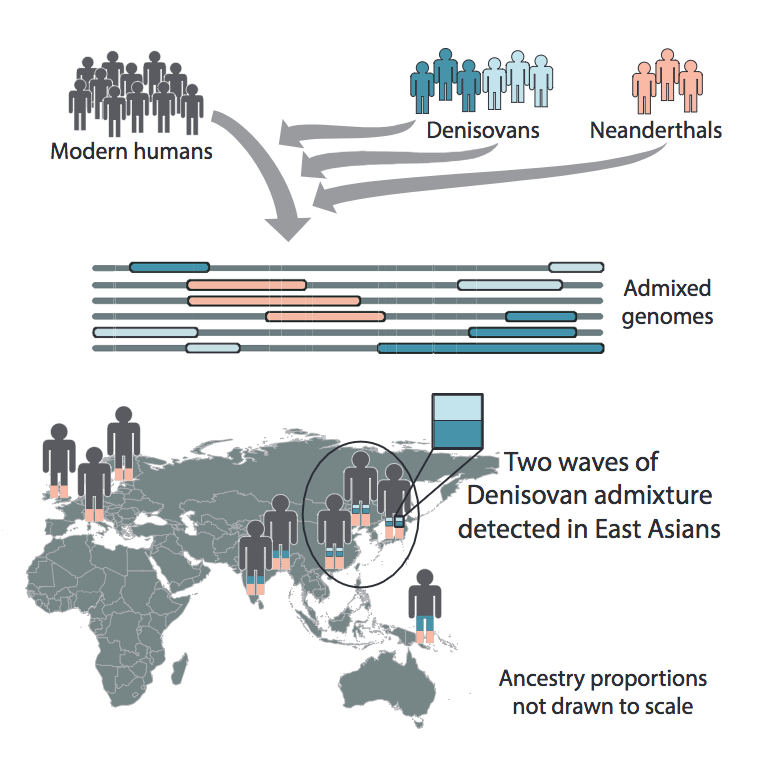

- **How separate or independent our we?**
  - perhaps…..just enough…..
  - 87 specific genes in modern humans are different from related genes in Neanderthals and Denisovans
  - Potential clues for our survival?

## Why did *Homo sapiens* win the survival race?

- **Was it key ‘human’ traits?**
  - many of these were shared (bi-pedalism, tools)
- **Was it evolution of larger brains?**
  - Neanderthals were slightly larger!
- **Was it fire?**
  - H.erectus may have used fire before we evolved
- **Was is related to social aspects?**
  - survival of the friendliest
- **Was it related to our adaptability**?
  - climate was unpredictable
- **Was it something non-human?**
  - superior microbiome
- **Was it luck?**
  - were we ‘independent’ enough?

[figure not shown]

## Independent or not, *Homo sapiens* have left our mark…

- **Human evolution → migration → agriculture → industrialization → Anthropocene**
- **What are the key milestones in human impact on Earth**
  - how far back do you think we need to go?
- **When did humans start impacting Appalachian ecosystems?**
  - early indigenous agriculture, coal mining era, ecological restoration efforts…

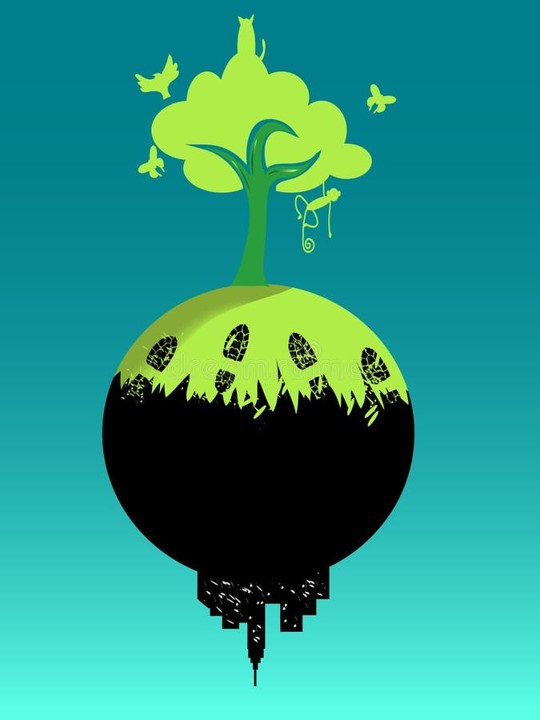

## *Homo sapiens* impacts: The beginning (review)

- **Genus Homo: ~2.5 million years ago**
- **Homo sapiens: ~300,000 years ago**
- **Coexistence with Neanderthals, Denisovans**
  - Homo sapiens ‘alone’ 40,000 ya
- **Appalachia: Indigenous presence ~12,000 years ago**

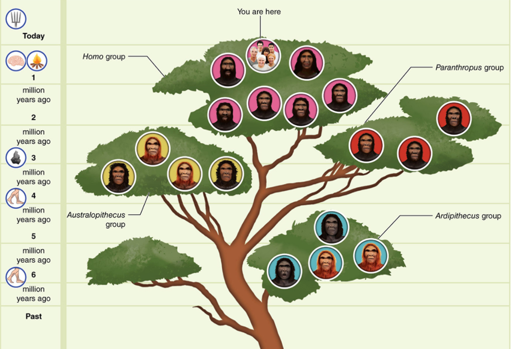

## Humans on the move

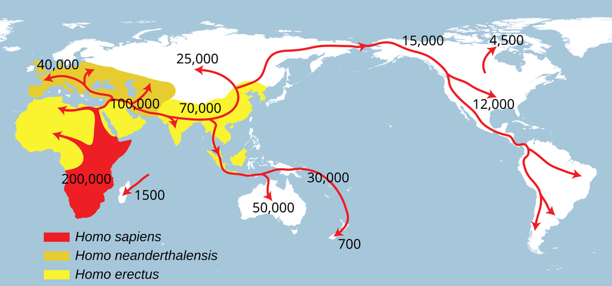

## *Homo sapiens* migration and megafauna impact

- *Homo sapiens* expansion linked to extinction of large mammals
  - During migration, >150 megafauna went extinct
  - sheep to mammoth sized
  - America’s and Australia most notable
- **Evidence in Eastern USA suggests hunting of megafauna**
  - clovis points (stone tools) found alongside megafauna remains
  - direct evidence in Appalachia is lacking
- **Climate change combined with overhunting may have accelerated extinctions**

[figure not shown]

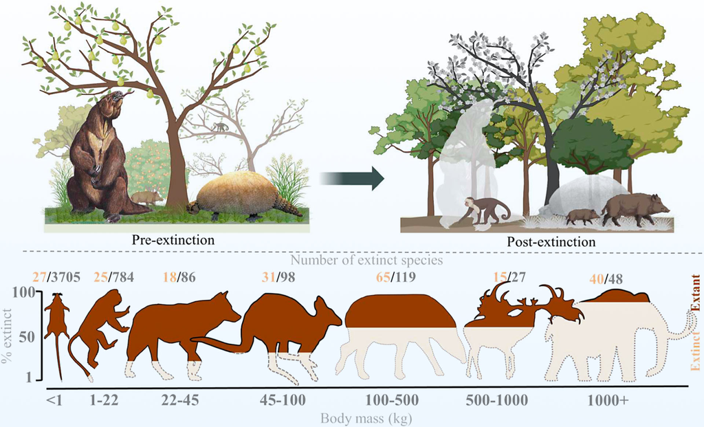

## The agricultural revolution was a game changer…

- **The end of the last Ice Age brought about warmer and more stable climates**
  - ~10,000 BCE at places like the ‘Fertile Crescent’
  - favorable conditions supported experimentation with plant cultivation
- **Humans domesticated plants and animals**
  - more predictable food supplies and the ability to store surplus
  - transition from nomadic hunting and gathering to settled farming communities.
- **Impact: Laid the foundation for the rise of permanent civilizations**

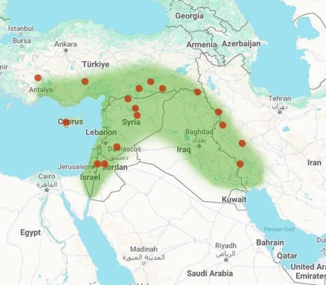

## Agricultural revolution key for population growth

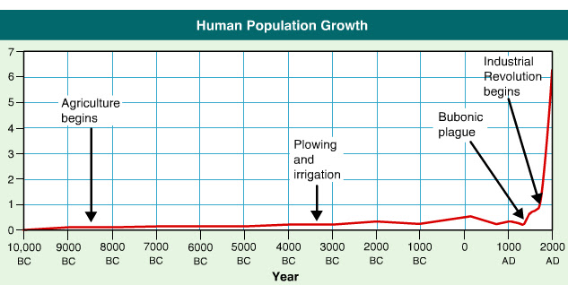

## Impacts of agricultural revolution

- **Increased impact on landscapes and biodiversity**
  - deforestation, soil quality, habitat loss
- **Start of land ownership and class divisions**
  - land ownership/inheritance as wealth
  - social stratification and inequality
  - new political structures
- **Enabled the emergence of trade networks and markets**
  - Case study: Hopewell culture in Ohio River Valley

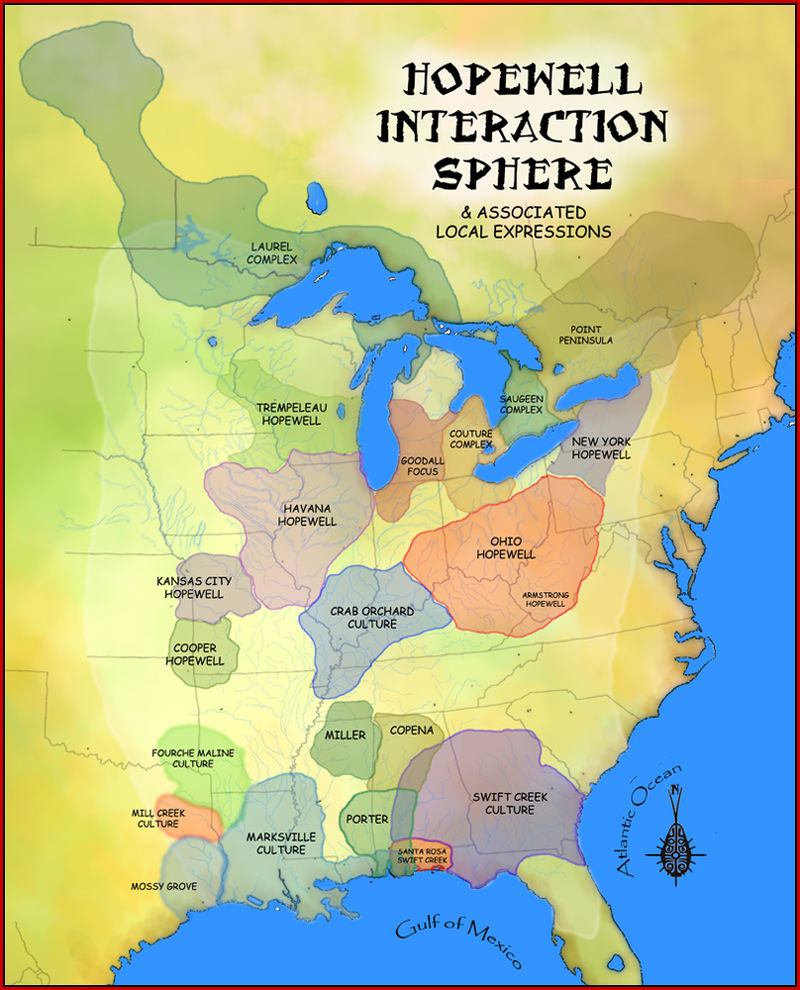

## Migration and Agriculture in context: Wildlife

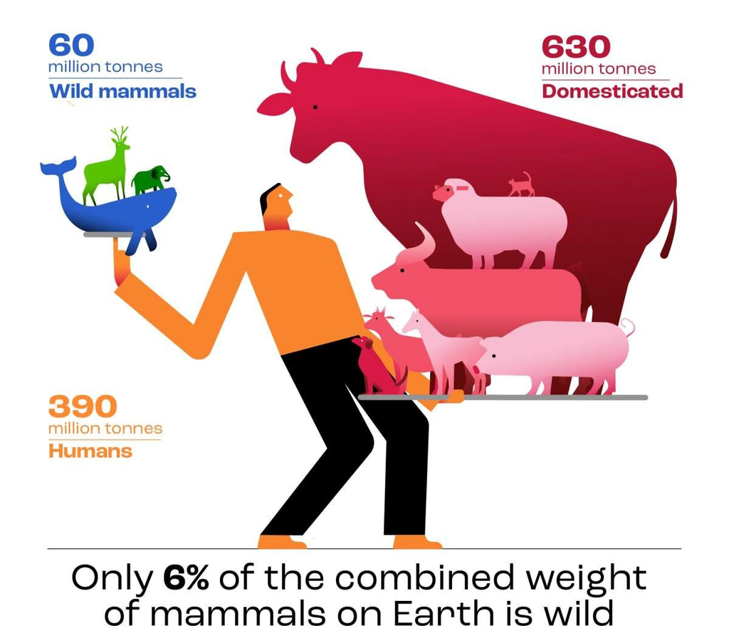

## Industrialization and the Human Footprint

- **Industrial Revolution began in the late 1700s in Britain, driven by coal, steam engines, and mechanized textile production**
- **Spread to Europe and North America in the 1800s, transforming economies and landscapes**
  - shift to fossil fuels (coal)
  - Led to urbanization, exponential growth in energy use, and mass production
- **Industrialization in USA ‘fueled’ by Appalachia**
  - rise of coal towns, railroad expansion, and deforestation

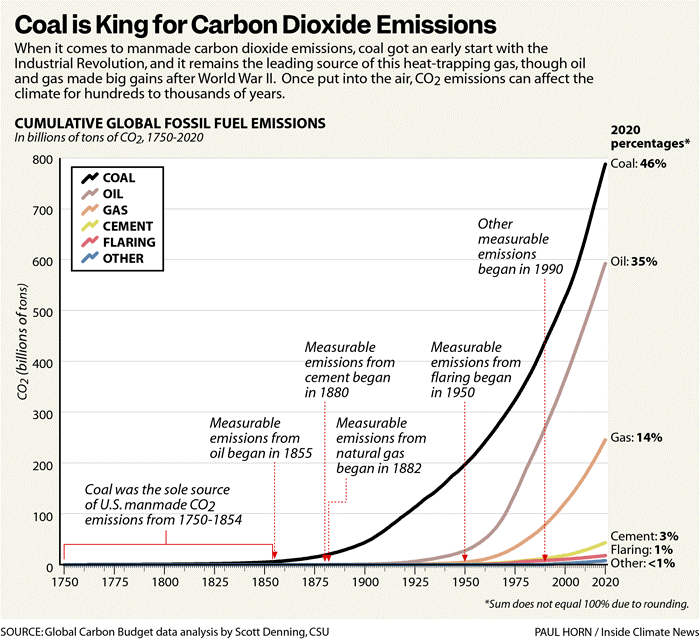

## Industrialization and the Human Footprint

**While driving economic and technological advancements, it has had a detrimental impact on the environment**

- **Environmental degradation: air and water pollution, mining scars, habitat destruction**
- **Societal consequences: rise of factory labor and child labor, income inequality, labor movements and strikes, migration to urban centers, and weakening of traditional rural communities**

[figure not shown]

## Industrialization beyond coal…

- **Water systems altered by dams, canals, and diversions**
  - disrupt aquatic life and natural flows.
- **Soil degradation from deforestation, erosion, and chemical farming**
  - reduces soil health and biodiversity.
- **Mining and factories polluted rivers with heavy metals and toxins**
  - Appalachia: Acid mine drainage turned streams orange, harmed fish and communities
- **Floods in Appalachia now made worse by compromised soils and hardened watersheds from past industrial activity**

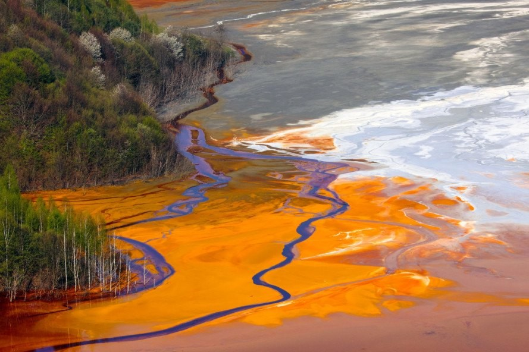

## Industrialization in context: Trees and humans

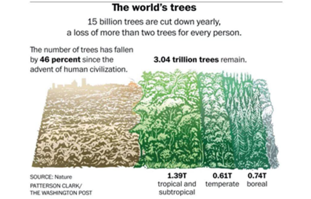

## Why does this matter for global change?

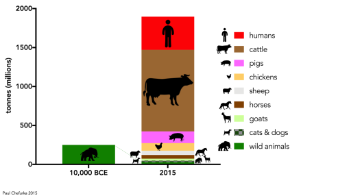

## Next Time: The Anthropocene

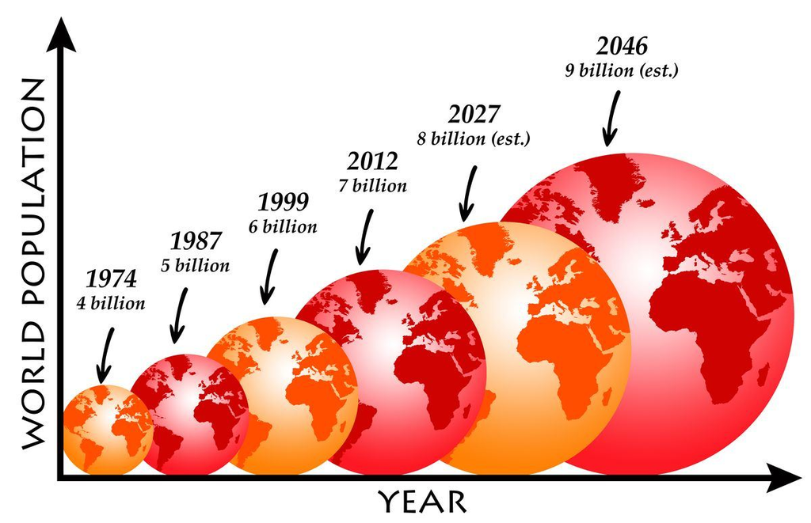